# R Notebook

```r
#load("/Users/markopeng/Desktop/msong_slhw.rdata")
load("msong_slhw.rdata")
logSequence = 10^seq(-2, 9, by=0.01)
msong_train = msong_train[complete.cases(msong_train),]
msong_test = msong_test[complete.cases(msong_test),]
sumds = function(ds) {
  nvariable = ncol(ds)
  varnames = colnames(ds)
  for(i in 1:nvariable) {
    tmp1 = ds[,i]
    #remove NA
    tmp1 = tmp1[!is.na(tmp1)]
    n = length(tmp1)
    mean = mean(tmp1)
    median = median(tmp1)
    sd = sd(tmp1)
    q13 = quantile(tmp1, c(0.25, 0.75))
    min1 = min(tmp1)
    max1 = max(tmp1)
    arow = c(n, mean, median, sd, q13, min1, max1)
    if(i==1) {
      out1 = arow
    } else {
      out1 = rbind(out1, arow)
    }
  }
  rownames(out1) = varnames
  colnames(out1) = c("n", "mean", "median", "sd", "Q1", "Q3", "Min", "Max")
  return(out1)
}
```

```r
sumds(msong_train)
```

```
##          n         mean      median          sd          Q1          Q3
## year 10000 1998.1868000 2002.000000   11.019966 1994.000000 2006.000000
## x1   10000   43.3271126   44.159280    6.070209   39.836132   47.763818
## x2   10000    1.1985093    8.719690   52.321661  -26.229055   36.323230
## x3   10000    8.6434885   10.561895   34.648990  -10.767837   29.264367
## x4   10000    0.9711060   -0.693125   15.870334   -8.422883    8.649355
## x5   10000   -6.4581155   -6.066075   22.548475  -20.823903    7.675220
## x6   10000   -9.6376147  -11.085815   12.744388  -18.438495   -2.355105
## x7   10000   -2.4694622   -2.126850   14.673932  -10.811212    6.460300
## x8   10000   -1.7809462   -1.638355    7.953511   -6.374542    2.890117
## x9   10000    3.7668685    3.945825   10.625117   -2.287780    9.978203
## x10  10000    1.8856856    1.774055    6.495955   -2.432295    6.160525
## x11  10000   -0.1170781   -0.023260    4.292850   -2.601485    2.487868
## x12  10000    2.4545137    2.279025    8.242975   -2.655935    7.336325
## x13  10000   33.7104484   29.095405   22.397000   18.198470   43.714585
## x14  10000 2415.2850226 1989.973190 1695.069508 1304.566253 3015.483785
## x15  10000 1967.7788832 1695.972455 1229.166685 1129.764350 2509.687338
## x16  10000 1500.4494553 1230.692730 1044.110775  820.202348 1873.518632
## x17  10000  911.5853973  816.350790  478.777515  607.986778 1092.359328
## x18  10000  871.2658655  734.747725  557.496833  489.286000 1107.038922
## x19  10000  604.9279793  546.527100  315.308493  394.959777  741.714085
## x20  10000  516.2329857  443.677520  303.125123  320.365612  624.049568
## x21  10000  396.2758057  352.005630  216.671184  258.026370  479.338035
## x22  10000  324.2071169  293.574185  162.406688  215.041875  396.294730
## x23  10000  285.7722003  240.523370  178.885619  167.817145  352.397670
## x24  10000  294.5213472  266.911260  158.274189  198.191408  352.007782
## x25  10000   43.4470525   26.555215  120.091330  -12.036922   87.369273
## x26  10000   40.0544845  -49.941145  710.937242 -288.263510  283.489700
## x27  10000  -40.1885044  -38.848035  541.586795 -249.637232  178.612705
## x28  10000  -23.6369413  -22.278125  218.675729 -117.526967   67.760810
## x29  10000   13.0605983    7.626745  159.561742  -61.668827   84.337515
## x30  10000   43.5502220   30.129945  132.856206  -24.043582   95.091675
## x31  10000    7.1706126    4.748565   99.566201  -38.342152   49.709393
## x32  10000   23.7570916   23.687800   72.595193   -7.250960   56.775225
## x33  10000   11.0866011    8.020255   74.918761  -23.915078   41.935570
## x34  10000   -5.0503928  -10.010350   48.880074  -29.637712   12.160485
## x35  10000    1.0133177    3.259075   42.232887  -16.533667   20.774015
## x36  10000   72.7693210   56.796860  106.979861   15.171990  118.023570
## x37  10000  -52.8300494  -75.205955  408.915052 -222.796675   80.838237
## x38  10000  121.6458765   80.560045  458.036500  -99.593805  309.122703
```

[output cut: 129 more lines]

```
## x76   -248.32263   161.33607
## x77  -4323.77527  3644.35104
## x78  -1725.41083  1373.93798
## x79  -3769.35798  1120.62270
## x80  -1990.44643  1281.30259
## x81   -210.76616   339.58053
## x82  -2879.88683  1528.98061
## x83   -634.30311  1808.80809
## x84  -1145.43876   931.34487
## x85   -157.65469   219.01800
## x86  -1029.05211   852.85366
## x87  -2481.44438  1309.30450
## x88    -65.77490   229.68655
## x89  -2380.79779  2881.36422
## x90   -179.77507   241.85549
```

```r
sumds(msong_test)
```

```
##          n          mean      median          sd          Q1           Q3
## year 51630 1998.49575828 2002.000000   10.852015 1995.000000 2006.0000000
## x1   51630   43.40183549   44.229145    5.962572   39.929720   47.8368225
## x2   51630    1.54519633    8.890255   51.281696  -25.184490   35.9814675
## x3   51630    8.73156404   10.548425   35.303265  -11.600835   29.9406525
## x4   51630    1.46375816   -0.319695   16.212757   -8.230815    9.0850150
## x5   51630   -6.92073021   -6.123600   22.902284  -20.933628    7.6800625
## x6   51630   -9.13081367  -11.018170   13.038397  -18.168130   -2.1228100
## x7   51630   -2.44928892   -2.038705   14.496472  -10.825130    6.4569400
## x8   51630   -1.78887029   -1.746645    7.981406   -6.531265    2.9842700
## x9   51630    3.84725212    3.889485   10.614668   -2.213935   10.0518950
## x10  51630    1.97121526    1.866745    6.595403   -2.413148    6.3131425
## x11  51630   -0.17708238   -0.113990    4.390092   -2.697500    2.4163325
## x12  51630    2.58773971    2.383270    8.291375   -2.462515    7.3404325
## x13  51630   34.11927032   29.337760   22.545268   18.461675   44.0658325
## x14  51630 2470.46151955 2036.814180 1761.158842 1330.593548 3086.1168125
## x15  51630 1991.37698992 1711.733060 1259.105377 1124.319798 2523.3083050
## x16  51630 1540.09136144 1258.273285 1091.080793  827.783660 1934.1362975
## x17  51630  915.90806752  821.543940  476.833613  606.870550 1106.9653375
## x18  51630  893.04855105  750.538350  578.157251  498.638940 1133.8775425
## x19  51630  608.59038335  545.181800  323.913463  395.058670  748.2854975
## x20  51630  530.22273337  451.568245  315.659221  324.773685  642.2175950
## x21  51630  395.35280303  350.179110  213.478838  257.545525  477.2580175
## x22  51630  332.00638260  296.971855  170.366967  217.460820  403.9577425
## x23  51630  294.70269116  245.639020  194.334292  169.886433  362.6588400
## x24  51630  290.46719882  263.099700  151.220204  196.471448  348.1985450
## x25  51630   42.55851176   27.258130  119.675302  -12.470350   88.3995900
## x26  51630   43.92184298  -44.854630  720.101774 -290.553132  290.9589800
## x27  51630  -47.37900656  -39.789040  543.978736 -253.769052  166.9493450
## x28  51630  -25.05799879  -21.144845  220.109937 -117.943187   67.9130075
## x29  51630   18.05236632   10.615425  162.622648  -57.986232   87.5824800
## x30  51630   43.17741733   29.916430  135.140777  -25.451130   97.8864900
## x31  51630    3.27829707    2.459865   98.441845  -41.036513   47.7321600
## x32  51630   24.46668609   23.506950   72.563098   -6.321583   56.4218650
## x33  51630    6.39561782    5.838890   74.022583  -27.320495   38.5608575
## x34  51630   -4.40957585   -9.821730   54.035962  -29.116985   12.4202000
## x35  51630   -0.73334785    2.558700   43.184664  -18.256485   20.2560950
## x36  51630   72.03210749   55.835610  107.656118   13.954292  116.7377625
## x37  51630  -49.07401597  -73.822190  410.204283 -224.907245   91.5850025
## x38  51630  123.20797044   82.892050  457.861052 -101.422467  312.8202825
```

[output cut: 129 more lines]

```
## x76    -526.29282   304.00001
## x77   -6711.60670  5774.76700
## x78   -2025.77816  1577.45007
## x79   -4665.40884  5188.32729
## x80   -3255.30880  2073.74271
## x81    -246.35782   504.32031
## x82   -3129.09361  1745.81442
## x83   -1110.46114  1710.52591
## x84   -1744.64651  1734.07969
## x85    -219.61419   169.21415
## x86   -1774.00158  2010.11756
## x87   -2854.34680  2032.43111
## x88    -157.34122   244.34180
## x89   -2506.95503  6946.62767
## x90    -381.42443   677.89963
```

```r
ridgeRegression = function(xmat, y, lambda){
  xmat = as.matrix(xmat)
  y = as.matrix(y)
  w = solve((diag(ncol(xmat)) * lambda) + (t(xmat) %*% xmat)) %*% t(xmat) %*% y
  return(w)
}

RMSE = function(t, y){
  return(sqrt( mean( (t - y)^2 , na.rm = TRUE ) ))
}
```

```r
# (2)
msong_train.5000 = msong_train[1:5000,]
sumds.5000 = sumds(msong_train.5000)
msong_train.5000.std = msong_train.5000
# scale training data
msong_train.5000.std$year = scale(msong_train.5000.std$year, scale=1)
msong_train.5000.std[,2:ncol(msong_train.5000.std)] = scale(msong_train.5000.std[,2:ncol(msong_train.5000.std)])
msong_train.5000.std.x = as.matrix(msong_train.5000.std[,2:ncol(msong_train.5000.std)])
msong_train.5000.std.y = as.matrix(msong_train.5000.std$year)
msong_train.5000.std.x = cbind(rep(1, nrow(msong_train.5000.std.x)), msong_train.5000.std.x)

# scale testing data
msong_test.q2.std = msong_test
msong_test.q2.std$year = scale(msong_test.q2.std$year, center=sumds.5000['year','mean'], scale=1)
msong_test.q2.std[,2:ncol(msong_test.q2.std)] = scale(msong_test.q2.std[,2:ncol(msong_test.q2.std)], center=sumds.5000[2:nrow(sumds.5000),'mean'], scale=sumds.5000[2:nrow(sumds.5000),'sd'])
msong_test.q2.std.x = as.matrix(msong_test.q2.std[,2:ncol(msong_test.q2.std)])
msong_test.q2.std.y = as.matrix(msong_test.q2.std$year)
msong_test.q2.std.x = cbind(rep(1, nrow(msong_test.q2.std.x)), msong_test.q2.std.x)
#
```

```r
# training and testing error
training.error = NULL
testing.error = NULL
x = NULL
for(i in logSequence){
  w = ridgeRegression(msong_train.5000.std.x, msong_train.5000.std.y, i)
  pred = msong_train.5000.std.x %*% w
  e = RMSE(pred,msong_train.5000.std.y)
  training.error = cbind(training.error, c((log10(i)), e))

  pred = msong_test.q2.std.x %*% w
  x = cbind(x, pred)
  e = RMSE(pred,msong_test.q2.std.y)
  testing.error = cbind(testing.error, c(log10(i), e))
}
```

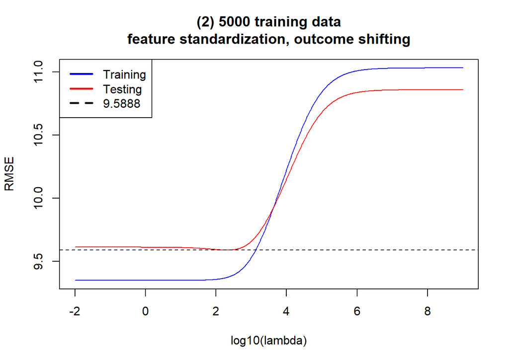

```r
top = max(max(training.error[2,]), max(testing.error[2,]))
bottom = min(min(training.error[2,]), min(testing.error[2,]))
plot(x=training.error[1,], y=training.error[2,], type='l', col='blue', xlab='log10(lambda)', ylab='RMSE', main='(2) 5000 training data\nfeature standardization, outcome shifting', ylim=c(bottom, top))
par(new=T)
plot(x=testing.error[1,], y=testing.error[2,], type='l', col='red', axes=F, xlab='', ylab='', ylim=c(bottom, top))

m = round(min(testing.error[2,]),digits=4)
abline(a=m,b=0,h = 0, lty = 2)
legend('topleft', legend=c("Training", "Testing", as.character(m)), col=c("blue", "red", "black"), lty=c("solid", "solid", "dashed"), lwd=2.5)
```

(2). 在lambda增加時，可以看到對training data的RMSE持續上升，原因是lambda增加時使model在training data上的overfitting情況減少，因為當feature過多時通常會越容易fit training data，regularization讓某些feature的權重降低(會減少模型複雜度)，因此model對training data的fit的程度下降。 而在Testing data上的表現在一開始會提升(RMSE下降)是因為regularization可以降低一些不重要feature的權重，將原本太多feature而過於複雜的模型簡單化，用真正有用的feature來預測沒看過的資料，後面RMSE會上升則是feature權重降的太低，model underfitting。

```r
# (3) 500
msong_train.500 = msong_train[1:500,]
sumds.500 = sumds(msong_train.500)
msong_train.500.std = msong_train.500
# scale training data
msong_train.500.std$year = scale(msong_train.500.std$year, scale=1)
msong_train.500.std[,2:ncol(msong_train.500.std)] = scale(msong_train.500.std[,2:ncol(msong_train.500.std)])
msong_train.500.std.x = as.matrix(msong_train.500.std[,2:ncol(msong_train.500.std)])
msong_train.500.std.y = as.matrix(msong_train.500.std$year)
msong_train.500.std.x = cbind(rep(1, nrow(msong_train.500.std.x)), msong_train.500.std.x)

# scale testing data
msong_test.q3.std = msong_test
msong_test.q3.std$year = scale(msong_test.q3.std$year, center=sumds.500['year','mean'], scale=1)
msong_test.q3.std[,2:ncol(msong_test.q3.std)] = scale(msong_test.q3.std[,2:ncol(msong_test.q3.std)], center=sumds.500[2:nrow(sumds.500),'mean'], scale=sumds.500[2:nrow(sumds.500),'sd'])
msong_test.q3.std.x = as.matrix(msong_test.q3.std[,2:ncol(msong_test.q3.std)])
msong_test.q3.std.y = as.matrix(msong_test.q3.std$year)
msong_test.q3.std.x = cbind(rep(1, nrow(msong_test.q3.std.x)), msong_test.q3.std.x)
```

```r
# training and testing error
training.error = NULL
testing.error = NULL
for(i in logSequence){
  w = ridgeRegression(msong_train.500.std.x, msong_train.500.std.y, i)

  pred = msong_train.500.std.x %*% w
  e = RMSE(pred,msong_train.500.std.y)
  training.error = cbind(training.error, c((log10(i)), e))

  pred = msong_test.q3.std.x %*% w
  e = RMSE(pred,msong_test.q3.std.y)
  testing.error = cbind(testing.error, c(log10(i), e))
}
```

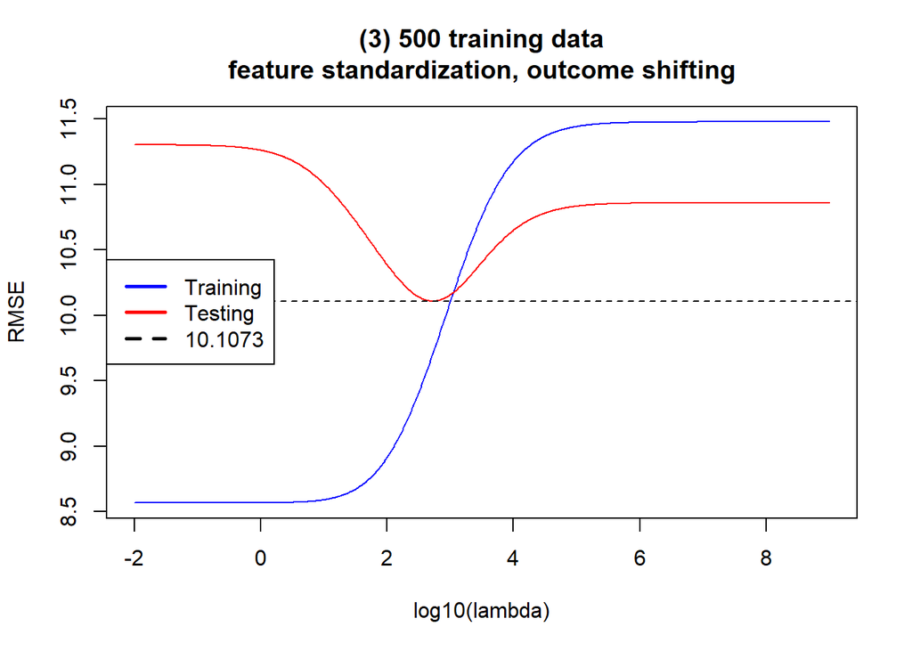

```r
top = max(max(training.error[2,]), max(testing.error[2,]))
bottom = min(min(training.error[2,]), min(testing.error[2,]))
plot(x=training.error[1,], y=training.error[2,], type='l', col='blue', xlab='log10(lambda)', ylab='RMSE', main='(3) 500 training data\nfeature standardization, outcome shifting', ylim=c(bottom, top))
par(new=T)
plot(x=testing.error[1,], y=testing.error[2,], type='l', col='red', axes=F, xlab='', ylab='', ylim=c(bottom, top))
m = round(min(testing.error[2,]),digits=4)
abline(a=m,b=0,h = 0, lty = 2)
legend('left', legend=c("Training", "Testing", as.character(m)), col=c("blue", "red", "black"), lty=c("solid", "solid", "dashed"), lwd=2.5)
```

```r
# (3) 1000
msong_train.1000 = msong_train[1:1000,]
sumds.1000 = sumds(msong_train.1000)
msong_train.1000.std = msong_train.1000
# scale training data
msong_train.1000.std$year = scale(msong_train.1000.std$year, scale=1)
msong_train.1000.std[,2:ncol(msong_train.1000.std)] = scale(msong_train.1000.std[,2:ncol(msong_train.1000.std)])
msong_train.1000.std.x = as.matrix(msong_train.1000.std[,2:ncol(msong_train.1000.std)])
msong_train.1000.std.y = as.matrix(msong_train.1000.std$year)
msong_train.1000.std.x = cbind(rep(1, nrow(msong_train.1000.std.x)), msong_train.1000.std.x)

# scale testing data
msong_test.q3.std = msong_test
msong_test.q3.std$year = scale(msong_test.q3.std$year, center=sumds.1000['year','mean'], scale=1)
msong_test.q3.std[,2:ncol(msong_test.q3.std)] = scale(msong_test.q3.std[,2:ncol(msong_test.q3.std)], center=sumds.1000[2:nrow(sumds.1000),'mean'], scale=sumds.1000[2:nrow(sumds.1000),'sd'])
msong_test.q3.std.x = as.matrix(msong_test.q3.std[,2:ncol(msong_test.q3.std)])
msong_test.q3.std.y = as.matrix(msong_test.q3.std$year)
msong_test.q3.std.x = cbind(rep(1, nrow(msong_test.q3.std.x)), msong_test.q3.std.x)
```

```r
# training and testing error
training.error = NULL
testing.error = NULL
for(i in logSequence){
  w = ridgeRegression(msong_train.1000.std.x, msong_train.1000.std.y, i)

  pred = msong_train.1000.std.x %*% w
  e = RMSE(pred,msong_train.1000.std.y)
  training.error = cbind(training.error, c((log10(i)), e))

  pred = msong_test.q3.std.x %*% w
  e = RMSE(pred,msong_test.q3.std.y)
  testing.error = cbind(testing.error, c(log10(i), e))
}
```

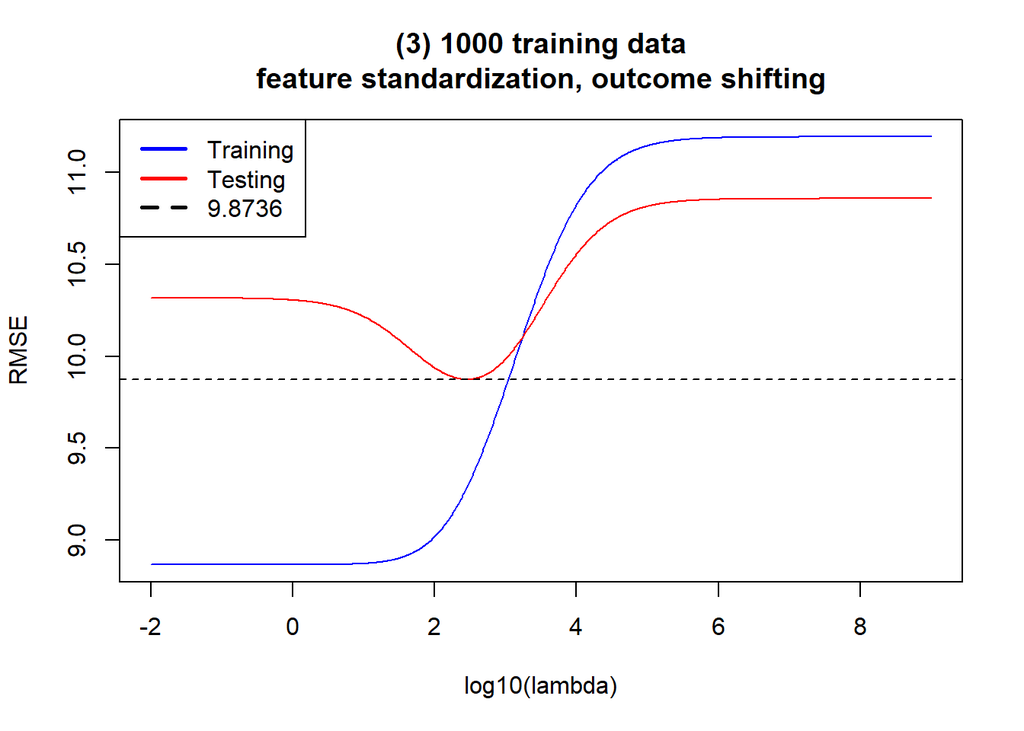

```r
top = max(max(training.error[2,]), max(testing.error[2,]))
bottom = min(min(training.error[2,]), min(testing.error[2,]))
plot(x=training.error[1,], y=training.error[2,], type='l', col='blue', xlab='log10(lambda)', ylab='RMSE', main='(3) 1000 training data\nfeature standardization, outcome shifting', ylim=c(bottom, top))
par(new=T)
plot(x=testing.error[1,], y=testing.error[2,], type='l', col='red', axes=F, xlab='', ylab='', ylim=c(bottom, top))
m = round(min(testing.error[2,]),digits=4)
abline(a=m,b=0,h = 0, lty = 2)
legend('topleft', legend=c("Training", "Testing", as.character(m)), col=c("blue", "red", "black"), lty=c("solid", "solid", "dashed"), lwd=2.5)
```

(3). 看到training error在500個training data時的起始點比較低(RMSE低)，應該是因為資料少，所以更容易fit全部的點，後面的曲線形狀類似。 但在testing error就是1000個training data的起始點比較低且最佳的RMSE也較低，符合常理，通常越多training data，在testing上表現也會較好。 觀察lambda的大小與testing error改善程度，看到在sample數500時在起始testing error與最佳的tseting error中的差距比在sample數1000時大，而在第二小題中的sample數5000時這個差距又更小了，可以推測當sample數量增大時regularization可以改善的testing error程度下降。

```r
# (4)
msong_train.1000 = msong_train[1:1000,]
sumds.1000 = sumds(msong_train.1000)
msong_train.1000.std = msong_train.1000
# scale training data y
msong_train.1000.std$year = scale(msong_train.1000.std$year, scale=1)
msong_train.1000.std.x = as.matrix(msong_train.1000.std[,2:ncol(msong_train.1000.std)])
msong_train.1000.std.y = as.matrix(msong_train.1000.std$year)
msong_train.1000.std.x = cbind(rep(1, nrow(msong_train.1000.std.x)), msong_train.1000.std.x)

# scale testing data
msong_test.q4.std = msong_test
msong_test.q4.std$year = scale(msong_test.q4.std$year, center=sumds.1000['year','mean'], scale=1)
msong_test.q4.std.x = as.matrix(msong_test.q4.std[,2:ncol(msong_test.q4.std)])
msong_test.q4.std.y = as.matrix(msong_test.q4.std$year)
msong_test.q4.std.x = cbind(rep(1, nrow(msong_test.q4.std.x)), msong_test.q4.std.x)
```

```r
# training and testing error
training.error = NULL
testing.error = NULL
for(i in logSequence){
  w = ridgeRegression(msong_train.1000.std.x, msong_train.1000.std.y, i)

  pred = msong_train.1000.std.x %*% w
  e = RMSE(pred,msong_train.1000.std.y)
  training.error = cbind(training.error, c((log10(i)), e))

  pred = msong_test.q4.std.x %*% w
  e = RMSE(pred,msong_test.q4.std.y)
  testing.error = cbind(testing.error, c(log10(i), e))
}
```

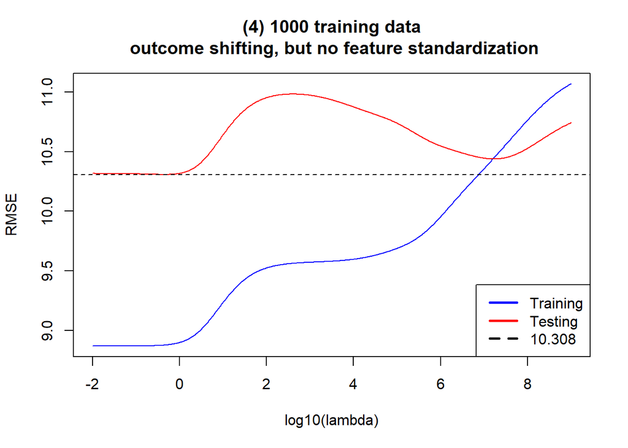

```r
top = max(max(training.error[2,]), max(testing.error[2,]))
bottom = min(min(training.error[2,]), min(testing.error[2,]))
plot(x=training.error[1,], y=training.error[2,], type='l', col='blue', xlab='log10(lambda)', ylab='RMSE', main='(4) 1000 training data\n outcome shifting, but no feature standardization', ylim=c(bottom, top))
par(new=T)
plot(x=testing.error[1,], y=testing.error[2,], type='l', col='red', axes=F, xlab='', ylab='', ylim=c(bottom, top))
m = round(min(testing.error[2,]),digits=4)
abline(a=m,b=0,h = 0, lty = 2)
legend('bottomright', legend=c("Training", "Testing", as.character(m)), col=c("blue", "red", "black"), lty=c("solid", "solid", "dashed"), lwd=2.5)
```

(4). Training和testing error都上升(最好的表現都在幾乎沒有regularization時)，顯示出regularization沒有用。 Regularization是要讓權重往0靠近，會給太大的coefficient一些penalty，舉個例子像是長度的單位，若是以公尺為單位時coefficient會比以公分為單位時大上很多(lambda=0時)，此時加入penalty term則不同尺度的feature會影響penalty term的程度會有差異。

為了讓feature對penalty term都有同等的影響力所以需要做feature standardization。 在這邊不standardize feature的best RMSE是10.308，且出現在lambda接近0的地方(代表不做regularization反而表現較好)， 前一題(3)有做standardization的最佳RMSE是9.8736，而最佳值出現在log lambda在2與3之間，代表regularization在那邊發揮作用。

```r
# (5)
msong_train.1000 = msong_train[1:1000,]
sumds.1000 = sumds(msong_train.1000)
msong_train.1000.std = msong_train.1000
# no scale training data y
msong_train.1000.std.x = as.matrix(msong_train.1000.std[,2:ncol(msong_train.1000.std)])
msong_train.1000.std.y = as.matrix(msong_train.1000.std$year)
msong_train.1000.std.x = cbind(rep(1, nrow(msong_train.1000.std.x)), msong_train.1000.std.x)

# no scale testing data
msong_test.q5.std = msong_test
msong_test.q5.std.x = as.matrix(msong_test.q5.std[,2:ncol(msong_test.q5.std)])
msong_test.q5.std.y = as.matrix(msong_test.q5.std$year)
msong_test.q5.std.x = cbind(rep(1, nrow(msong_test.q5.std.x)), msong_test.q5.std.x)
```

```r
# training and testing error
training.error = NULL
testing.error = NULL
for(i in logSequence){
  w = ridgeRegression(msong_train.1000.std.x, msong_train.1000.std.y, i)

  pred = msong_train.1000.std.x %*% w
  e = RMSE(pred,msong_train.1000.std.y)
  training.error = cbind(training.error, c((log10(i)), e))

  pred = msong_test.q5.std.x %*% w
  e = RMSE(pred,msong_test.q5.std.y)
  testing.error = cbind(testing.error, c(log10(i), e))
}
```

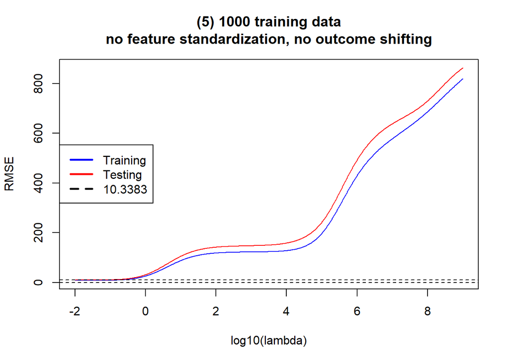

```r
top = max(max(training.error[2,]), max(testing.error[2,]))
bottom = min(min(training.error[2,]), min(testing.error[2,]))
plot(x=training.error[1,], y=training.error[2,], type='l', col='blue', xlab='log10(lambda)', ylab='RMSE', main='(5) 1000 training data\nno feature standardization, no outcome shifting' , ylim=c(bottom, top))
par(new=T)
plot(x=testing.error[1,], y=testing.error[2,], type='l', col='red', axes=F, xlab='', ylab='', ylim=c(bottom, top))
m = round(min(testing.error[2,]),digits=4)
abline(a=m,b=0,h = 0, lty = 2)
legend('left', legend=c("Training", "Testing", as.character(m)), col=c("blue", "red", "black"), lty=c("solid", "solid", "dashed"), lwd=2.5)
```